# How Does Gentrification Change Landlord Behavior?

Sam Gass

# What happens to housing quality when real estate prices go up?

As rents in New York have soared over the past twenty years, displacement of native New Yorkers has become a rampant issue. As new, wealthier residents have moved to previously affordable neighborhoods prices of goods, services and real estate have escalated beyond the economic means of current residents and forced many if not most of them to move. Often neglected in the discussion of the forces that push tenants to leave their communities is the role of the landlord or building owner in the process.

In New York City, rent control and stabilization are two of the primary defenses against the potential displacement of tenants. When rents increase, these protections prevent landlords from renting out the units at higher rates or from selling their buildings for large profits. This dynamic can generate tension between a building owner and rent stabilized or controlled tenants who stand in the way of profits. Those living in areas that are gentrifying will often claim that their landlords are neglecting or harassing them in order to force them out of the building. As I searched for academic literature or journalistic writing about this specific phenomenon, I came up short. I sought to, in this article, provide some quantitative evidence as to the existence of this tenant landlord relationship that I, having lived in New York City for three years, had come to hear so much about.

# The Data

Finding data that gave some insight into this real-world issue was a challenging undertaking. I needed variables that could act as reasonably accurate barometers for the changes in these neighborhoods, the outcome for the tenants, the policy protections granted to these tenants, and some controls for outside variables. In the end I settled on a combination of open source data sets that I believe serve as better than expected representations of these individual phenomenon.

## 311 Call Logs

To represent the outcome data, the perceived change in landlord behavior and quality of housing, in this analysis I scraped 14 years of 311 call logs from 2003-2017. The 311 call line is a NYC government-run service that receives complaints or questions about New York City from its residents. The service accepts and documents complaints pertaining to a wide-range of issues from noise complaints to rat sightings. In each available year there are over 8 million individual records of complaints. This analysis focuses on complaints designated as under the purview of Housing Preservation and Development (HPD). These include tenant complaints about their housing and building conditions which potentially violate the New York City Housing Maintenance Code (HMC) or the New York State Multiple Dwelling Law (MDL).

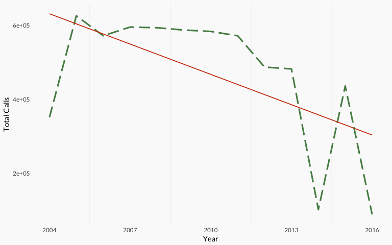

The total number of HPD Complaints also varies widely by tract, with the average number of calls per tract per year at 232. There is significant variation in this variable with a standard deviation of 339 calls.

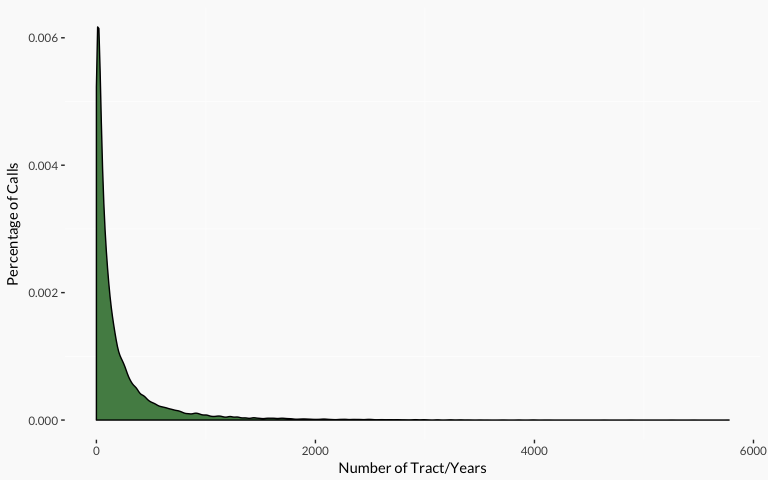

Call totals varied significantly by census tract, with high-concentration pockets in Brooklyn, Queens, Upper Manhattan, and the Bronx. This map outlines the extent of this inequitable distribtion:

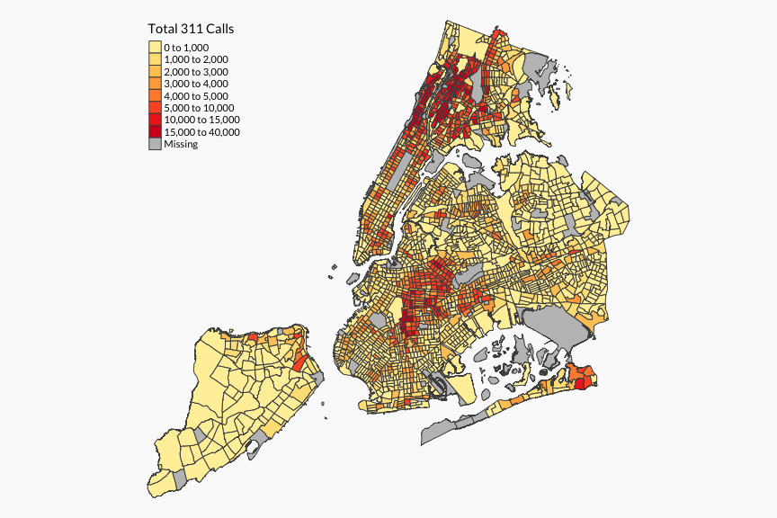

The calls also varied by type of complaint – with heating issues as the most common by far followed by construction, plumbing, and paint.

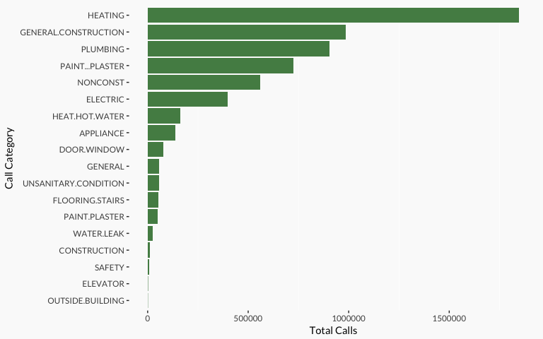

## Real Estate Prices

To calculate this real estate sales data, I scraped from the Rolling Sales Data available from the NYC Department of Finance (DOF). This data includes a summary of each individual property sale in New York City from 2003-2016. To run this analysis, I scraped the data and then calculated the median price of one square foot of residential property in each census tract per year of available data.

Each individual row of the data represents a single property sale in New York City. The data includes the address of the property, the price of the sale, the tax designation of the property, the square footage, the zip code, and the zoning designation. To summarize by census tract, I merged with the Pluto record from the matching year.

If we look at the average price in each year, we can see the steep uptick in prices starting in 2012. Minus the 4 year dip during the recession, residential real estate prices have steadily risen since 2004.

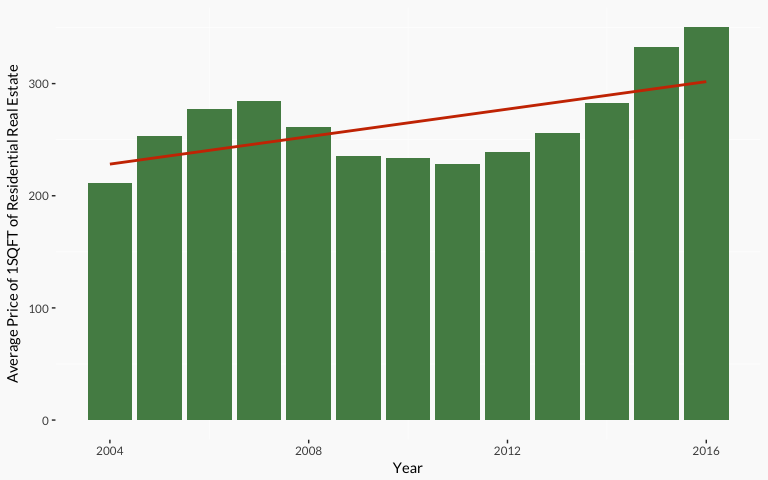

By mapping out the average price in NYC census tracts from available years, we can create a topline view of the residential real estate price distribution on average in the city during this time:

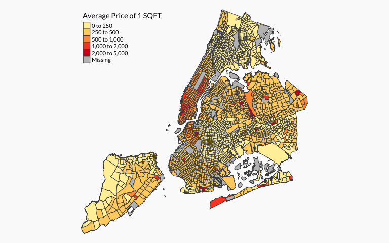

The stark contrast between the first year of available data (2004) and the last year (2016) shows us just how much the city has changed in terms of real estate affordability in the last twenty years. Neighborhoods that had been affordable for generations all of a sudden saw an influx of high-income buyers and renters.

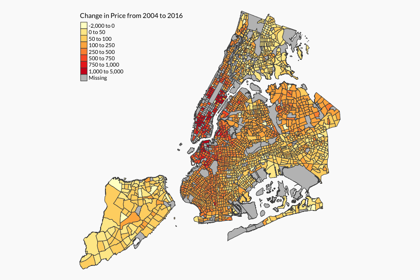

Notice not only the dramatic increase in Manhattan, but the stark rise in previously affordable neighborhoods in Brooklyn and Queens. Higher residential real estate costs not only mean more expensive for buyers, but renters as well. As the red pushes to the outer boroughs in the map, those neighborhoods become unaffordable for renters who live in the neighborhood. This creates a chain reaction of people being pushed out towards the outer parts of the outer boroughs and the current residents of those neighborhoods being pushed out of the city altogether or into untenable living situations.

## Rent Control/Stabilization

It proved very difficult to find or aggregate any records about rent stabilized or controlled units in New York City. The agency in charge of overseeing the system, The New York State Department of Homes and Community Renewal (DHCR), does not make yearly lists of rent stabilized units in New York City available. In addition, yearly registration with the DHCR, which any building owner with rent stabilized or controlled units is supposed to do, is self-reported.

Luckily, I was able to find a data set scraped from the New York City tax records by John Krauss [@krauss]. This data set uses tax bills which are publicly available in pdf form online for every year 2007-2014. Tax bills for individual buildings list the number of stabilized units registered to that building each year. Krauss and his team used pdf scraping technology to extract data from the pdf records. The data contains the records for 44,911 buildings in New York City that were known to have a stabilized unit in them during that time span. For each building, there is a record for each of the years in that time span that include the number of stabilized units in the building that year.

There are multiple drawbacks in this data set. First, because there is no penalty to fail to register with the DHCR in a given year, there are numerous missing records in specific years in which a building simply forgot to register. To account for this, Krauss and his team employed estimation techniques to fill in the missing data:

```
If there is no stabilized unit count for a building that had one the previous year, the
previous year's number is used in any of the following cases:

  • The bill without a unit count had a SCRIE or DRIE abatement, indicating the continued
  presence of regulated units.
  • The bill without a unit count maintained the same abatements as the previous year (for
  example 421a or J51) indicating that restrictions mandating affordability remained in
  effect.
  • The building appeared on HCR's stabilized building list for the year without a unit
  count, indicating that it was in fact still stabilized. (Krauss 2014)
```

The map below identifies the uneven distribution of rent stabilization in the city, with high concentration pockets spread throughout the boroughs, with especially high volume tracts in Manhattan and the Bronx and spread throughout Brooklyn:

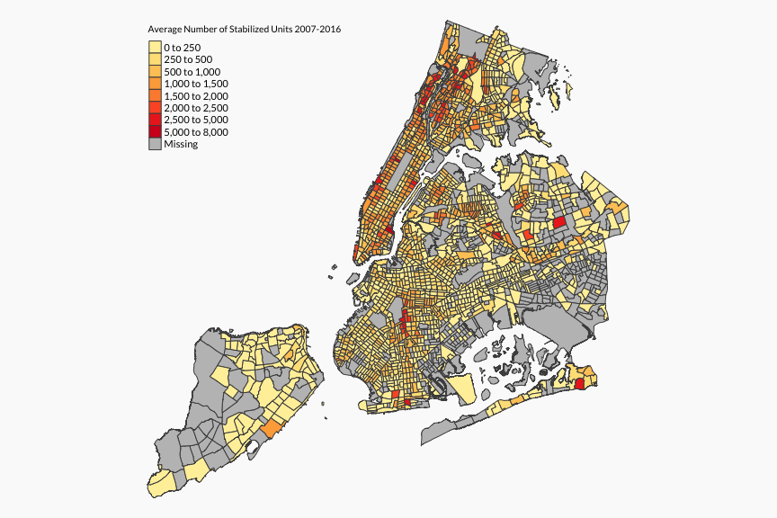

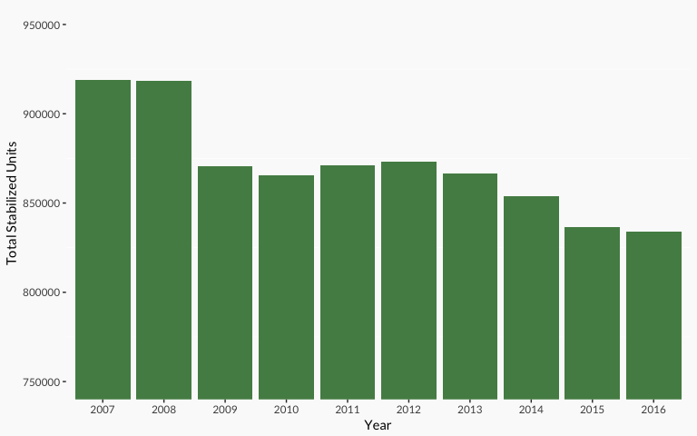

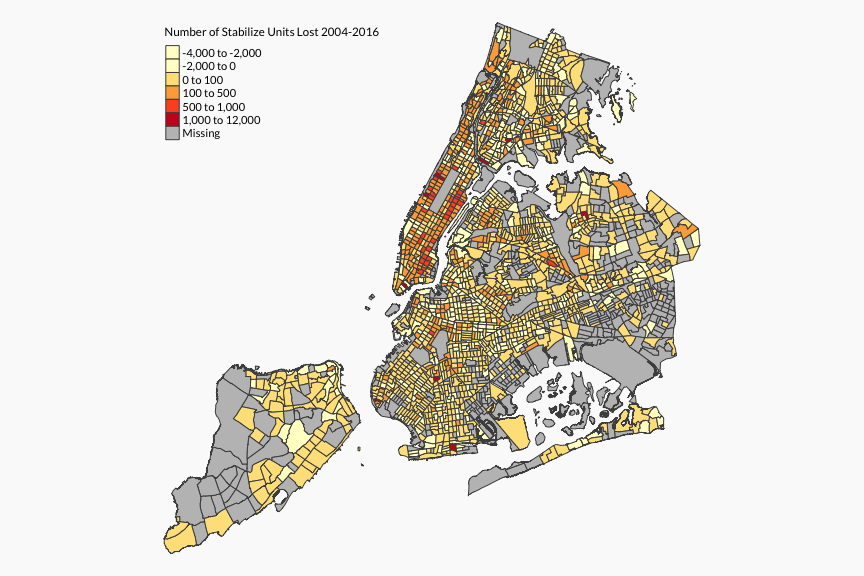

# Defining Gentrification

Perhaps the most challenging process of this study was creating thresholds for ‘gentrification’ of a census tract. Admittedly, the definition of gentrification and the debate over its nuances exists outside the scope of this analysis. Gentrification has many dimensions outside of cost of living, and to simplify the process and allow for more temporal and geographic granularity, I excluded them from this study. I did, however, adapt a previously formed definition of gentrification to the real estate data I collected in order to identify “gentrified” (by my own definition) tracts during the period of study.

I adapted this measurement to my variables by first identifying tracts whose average price of one square foot of residential real estate between 2004-2005 (to control for outlines) was below the city median. These tracts were considered gentrified if this price increased above the city wide median between this time period and 2015-2016. If a tract satisfied both of these qualifications, it was marked as gentrified (Gentrified dummy = 1).

Tracts that were marked as gentrified received one additional variable, the year in which they gentrified. This variable was created by first identifying the residential real estate percentile among all tracts for each tract in each year. For example, if the price of one square foot of residential real estate was the highest in a particular tract in a particular year, this tract was marked as the 100th percentile in that year. After this the year-to-year percentile jump was calculated, ie if in one year the tract was in the 25th percentile and in the following year was in the 30th percentile the jump variable was marked as 5%.

Once these two variables were calculated, tracts marked as gentrified were separated out from the data set. The year in which they gentrified was identified as the year in which the percentile increase was greatest if the average percentile in the following years did not fall below the percentile in the identified year. For example, if the maximum percentile jump for a tract was 25 percentiles, the year in which this occurred was identified as the gentrifying year if the average percentile in the subsequent years did not fall below the percentile from that year. If they did, the second highest jump was used and so on.

The results of the variable creation returned a very plausible list of tracts, most of which a New York City will recognize as in the neighborhoods most discussed during a discourse on gentrification in the city:

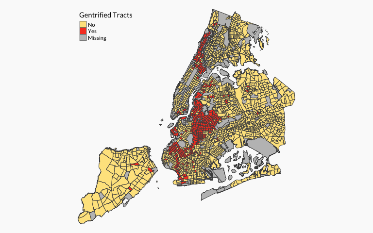

# Analysis